# QUESTION

```
• DOMAIN: Smartphone, Electronics


• CONTEXT: India is the second largest market globally for smartphones after China. About 134 million smartphones were sold across India in the year 2017 and is estimated to increase to about 442 million in 2022. India ranked second in the average time spent on mobile web by smartphone users across Asia Pacific. The combination of very high sales volumes and the average smartphone consumer behaviour has made India a very attractive market for foreign vendors. As per Consumer behaviour, 97% of consumers turn to a search engine when they are buying a product vs. 15% who turn to social media. If a seller succeeds to publish smartphones based on user’s behaviour/choice at the right place, there are 90% chances that user will enquire for the same. This Case Study is targeted to build a recommendation system based on individual consumer’s behaviour or choice.


• DATA DESCRIPTION:
    • author : name of the person who gave the rating
    • country : country the person who gave the rating belongs to
    • data : date of the rating
    • domain: website from which the rating was taken from
    • extract: rating content
    • language: language in which the rating was given
    • product: name of the product/mobile phone for which the rating was given
    • score: average rating for the phone
    • score_max: highest rating given for the phone
    • source: source from where the rating was taken


• PROJECT OBJECTIVE: We will build a recommendation system using popularity based and collaborative filtering methods to recommend mobile phones to a user which are most popular and personalised respectively.


    Steps and tasks: [ Total Score: 60 points]


        1. Import the necessary libraries and read the provided CSVs as a data frame and perform the below steps. [15 Marks]
            A. Merge all the provided CSVs into one data-frame. [2 Marks]
            B. Explore, understand the Data and share at least 2 observations. [2 Marks]
            C. Round off scores to the nearest integers. [3 Marks]
            D. Check for missing values. Impute the missing values, if any. [2 Marks]
            E. Check for duplicate values and remove them, if any. [2 Marks]
            F. Keep only 1 Million data samples. Use random state=612. [2 Marks]
            G. Drop irrelevant features. Keep features like Author, Product, and Score. [2 Marks]

        2. Answer the following questions. [10 Marks]
            A. Identify the most rated features. [3 Marks]
            B. Identify the users with most number of reviews. [3 Marks]
            C. Select the data with products having more than 50 ratings and users who have given more than 50 ratings. Report the shape of the final dataset. [4 Marks]

        3. Build a popularity based model and recommend top 5 mobile phones. [5 Marks]

        4. Build a collaborative filtering model using SVD. You can use SVD from surprise or build it from scratch(Note: Incase you’re building it from scratch you can limit your data points to 5000 samples if you face memory issues). Build a collaborative filtering model using kNNWithMeans from surprise. You can try both user-based and item-based model. [10 Marks]

        5. Evaluate the collaborative model. Print RMSE value. [2 Marks]

        6. Predict score (average rating) for test users. [2 Marks]

        7. Report your findings and inferences. [2 Marks]

        8. Try and recommend top 5 products for test users. [5 Marks]

        9. Try other techniques (Example: cross validation) to get better results. [3 Marks]

        10. In what business scenario you should use popularity based Recommendation Systems ? [2 Marks]

        11. In what business scenario you should use CF based Recommendation Systems ? [2 Marks]

        12. What other possible methods can you think of which can further improve the recommendation for different users ? [2 Marks]
```

**1. Import the necessary libraries and read the provided CSVs as a data frame and perform the below steps. [15 Marks]**

**A. Merge all the provided CSVs into one data-frame. [2 Marks]**

**B. Explore, understand the Data and share at least 2 observations. [2 Marks]**

**C. Round off scores to the nearest integers. [3 Marks]**

**D. Check for missing values. Impute the missing values, if any. [2 Marks]**

**E. Check for duplicate values and remove them, if any. [2 Marks]**

**F. Keep only 1 Million data samples. Use random state=612. [2 Marks]**

**G. Drop irrelevant features. Keep features like Author, Product, and Score. [2 Marks]**

```python
#Import Libraries
# To enable plotting graphs in Jupyter notebook
%matplotlib inline
import numpy as np
import pandas as pd
from sklearn.tree import DecisionTreeClassifier
from sklearn.tree import export_graphviz
from os import system
from IPython.display import Image
from sklearn.tree import plot_tree

from scipy.stats import zscore
import seaborn as sns
import matplotlib.pyplot as plt
sns.set(color_codes=True) # adds a nice background to the graphs
from sklearn.metrics import classification_report, confusion_matrix, roc_auc_score, roc_curve, accuracy_score, precision_score, recall_score,f1_score
import os
from sklearn.preprocessing import LabelEncoder
from scipy import stats
%matplotlib inline
sns.set_style('darkgrid')
%matplotlib inline
from sklearn.preprocessing import MinMaxScaler
from sklearn import model_selection
import warnings
warnings.filterwarnings("ignore")
from collections import Counter
from sklearn.model_selection import cross_val_score
from imblearn.over_sampling import RandomOverSampler
from imblearn.over_sampling import SMOTENC
from imblearn.over_sampling import SMOTE
# Confusion Matrix
from sklearn import metrics
from sklearn.model_selection import train_test_split, GridSearchCV,RandomizedSearchCV
from sklearn.cluster import KMeans
from sklearn.preprocessing import LabelEncoder
from sklearn.preprocessing import MinMaxScaler
import seaborn as sns
import matplotlib.pyplot as plt
from matplotlib import cm
from sklearn.cluster import AgglomerativeClustering
from IPython.display import display
from scipy.spatial.distance import cdist
from pandas.api.types import is_numeric_dtype
from sklearn import svm
from sklearn.decomposition import PCA
from sklearn.metrics import silhouette_samples, silhouette_score
from scipy.cluster.hierarchy import cophenet, dendrogram, linkage
from scipy.spatial.distance import pdist  #Pairwise distribution between data points
from scipy.cluster.hierarchy import fcluster
# Import Linear Regression machine learning library
from sklearn.linear_model import LinearRegression
from sklearn.linear_model import Ridge
from sklearn.linear_model import Lasso
from sklearn.preprocessing import StandardScaler

from sklearn.linear_model import LogisticRegression
from sklearn.neighbors import KNeighborsClassifier
from lightgbm import LGBMClassifier
from sklearn.ensemble import GradientBoostingClassifier
from xgboost import XGBClassifier
from sklearn.ensemble import RandomForestClassifier
from sklearn.svm import SVC, LinearSVC
from sklearn.feature_selection import SelectFromModel
import xgboost as xgb
from imblearn.pipeline import Pipeline
from imblearn.combine import SMOTETomek
from sklearn.model_selection import StratifiedKFold
from sklearn.model_selection import cross_validate
import pickle
from sklearn.compose import ColumnTransformer
from sklearn.preprocessing import OneHotEncoder
from sklearn.impute import SimpleImputer
from sklearn.preprocessing import FunctionTransformer


# Libraries for recommendation systems
from collections import defaultdict
from surprise import SVD
from surprise import KNNWithMeans
from surprise import Dataset
from surprise import accuracy
from surprise import Reader
from surprise.model_selection import cross_validate
from surprise.model_selection import train_test_split
```

[output not shown]

## 1. Import the necessary libraries and read the provided CSVs as a data frame and perform the below steps. [15 Marks]

### A. Merge all the provided CSVs into one data-frame. [2 Marks]

```python
df1 = pd.read_csv("phone_user_review_file_1.csv")
df2 = pd.read_csv("phone_user_review_file_2.csv")
df3 = pd.read_csv("phone_user_review_file_3.csv")
df4 = pd.read_csv("phone_user_review_file_4.csv")
df5 = pd.read_csv("phone_user_review_file_5.csv")
df6 = pd.read_csv("phone_user_review_file_6.csv")
```

```python
print('Top 2 rows of the data1: ')
display(df1.head(2))
print('Top 2 rows of the data 2 : ')
display(df2.head(2))
print('Top 2 rows of the data 3 : ')
display(df3.head(2))
print('Top 2 rows of the data 4 : ')
display(df4.head(2))
print('Top 2 rows of the data 5 : ')
display(df5.head(2))
print('Top 2 rows of the data 6 : ')
display(df6.head(2))
```

```
Top 2 rows of the data1:
```

|  | phone_url | date | lang | country | source | domain | score | score_max | extract | author | product |
| --- | --- | --- | --- | --- | --- | --- | --- | --- | --- | --- | --- |
| 0 | /cellphones/samsung-galaxy-s8/ | 5/2/2017 | en | us | Verizon Wireless | verizonwireless.com | 10.0 | 10.0 | As a diehard Samsung fan who has had every Sam... | CarolAnn35 | Samsung Galaxy S8 |
| 1 | /cellphones/samsung-galaxy-s8/ | 4/28/2017 | en | us | Phone Arena | phonearena.com | 10.0 | 10.0 | Love the phone. the phone is sleek and smooth ... | james0923 | Samsung Galaxy S8 |

```
Top 2 rows of the data 2 :
```

|  | phone_url | date | lang | country | source | domain | score | score_max | extract | author | product |
| --- | --- | --- | --- | --- | --- | --- | --- | --- | --- | --- | --- |
| 0 | /cellphones/leagoo-lead-7/ | 4/15/2015 | en | us | Amazon | amazon.com | 2.0 | 10.0 | The telephone headset is of poor quality , not... | luis | Leagoo Lead7 5.0 Inch HD JDI LTPS Screen 3G Sm... |
| 1 | /cellphones/leagoo-lead-7/ | 5/23/2015 | en | gb | Amazon | amazon.co.uk | 10.0 | 10.0 | This is my first smartphone so I have nothing ... | Mark Lavin | Leagoo Lead 7 Lead7 MTK6582 Quad core 1GB RAM ... |

```
Top 2 rows of the data 3 :
```

|  | phone_url | date | lang | country | source | domain | score | score_max | extract | author | product |
| --- | --- | --- | --- | --- | --- | --- | --- | --- | --- | --- | --- |
| 0 | /cellphones/samsung-galaxy-s-iii-slim-sm-g3812/ | 11/7/2015 | pt | br | Submarino | submarino.com.br | 6.0 | 10.0 | recomendo, eu comprei um, a um ano, e agora co... | herlington tesch | Samsung Smartphone Samsung Galaxy S3 Slim G381... |
| 1 | /cellphones/samsung-galaxy-s-iii-slim-sm-g3812/ | 10/2/2015 | pt | br | Submarino | submarino.com.br | 10.0 | 10.0 | Comprei um pouco desconfiada do site e do celu... | Luisa Silva Marieta | Samsung Smartphone Samsung Galaxy S3 Slim G381... |

```
Top 2 rows of the data 4 :
```

|  | phone_url | date | lang | country | source | domain | score | score_max | extract | author | product |
| --- | --- | --- | --- | --- | --- | --- | --- | --- | --- | --- | --- |
| 0 | /cellphones/samsung-s7262-duos-galaxy-ace/ | 3/11/2015 | en | us | Amazon | amazon.com | 2.0 | 10.0 | was not conpatable with my phone as stated. I ... | Frances DeSimone | Samsung Galaxy Star Pro DUOS S7262 Unlocked Ce... |
| 1 | /cellphones/samsung-s7262-duos-galaxy-ace/ | 17/11/2015 | en | in | Zopper | zopper.com | 10.0 | 10.0 | Decent Functions and Easy to Operate Pros:- Th... | Expert Review | Samsung Galaxy Star Pro S7262 Black |

```
Top 2 rows of the data 5 :
```

|  | phone_url | date | lang | country | source | domain | score | score_max | extract | author | product |
| --- | --- | --- | --- | --- | --- | --- | --- | --- | --- | --- | --- |
| 0 | /cellphones/karbonn-k1616/ | 7/13/2016 | en | in | 91 Mobiles | 91mobiles.com | 2.0 | 10.0 | I bought 1 month before. currently speaker is ... | venkatesh | Karbonn K1616 |
| 1 | /cellphones/karbonn-k1616/ | 7/13/2016 | en | in | 91 Mobiles | 91mobiles.com | 6.0 | 10.0 | I just bought one week back, I have Airtel con... | Venkat | Karbonn K1616 |

```
Top 2 rows of the data 6 :
```

|  | phone_url | date | lang | country | source | domain | score | score_max | extract | author | product |
| --- | --- | --- | --- | --- | --- | --- | --- | --- | --- | --- | --- |
| 0 | /cellphones/samsung-instinct-sph-m800/ | 9/16/2011 | en | us | Phone Arena | phonearena.com | 8.0 | 10.0 | I've had the phone for awhile and it's a prett... | ajabrams95 | Samsung Instinct HD |
| 1 | /cellphones/samsung-instinct-sph-m800/ | 2/13/2014 | en | us | Amazon | amazon.com | 6.0 | 10.0 | to be clear it is not the sellers fault that t... | Stephanie | Samsung SPH M800 Instinct |

```python
display(df1.shape)
display(df2.shape)
display(df3.shape)
display(df4.shape)
display(df5.shape)
display(df6.shape)
```

```
(374910, 11)
```

```
(114925, 11)
```

```
(312961, 11)
```

```
(98284, 11)
```

```
(350216, 11)
```

```
(163837, 11)
```

```python
df = pd.concat([df1, df2, df3, df4, df5, df6], ignore_index=True)
```

```python
df.shape
```

```
(1415133, 11)
```

```python
df.head()
```

|  | phone_url | date | lang | country | source | domain | score | score_max | extract | author | product |
| --- | --- | --- | --- | --- | --- | --- | --- | --- | --- | --- | --- |
| 0 | /cellphones/samsung-galaxy-s8/ | 5/2/2017 | en | us | Verizon Wireless | verizonwireless.com | 10.0 | 10.0 | As a diehard Samsung fan who has had every Sam... | CarolAnn35 | Samsung Galaxy S8 |
| 1 | /cellphones/samsung-galaxy-s8/ | 4/28/2017 | en | us | Phone Arena | phonearena.com | 10.0 | 10.0 | Love the phone. the phone is sleek and smooth ... | james0923 | Samsung Galaxy S8 |
| 2 | /cellphones/samsung-galaxy-s8/ | 5/4/2017 | en | us | Amazon | amazon.com | 6.0 | 10.0 | Adequate feel. Nice heft. Processor's still sl... | R. Craig | Samsung Galaxy S8 (64GB) G950U 5.8" 4G LTE Unl... |
| 3 | /cellphones/samsung-galaxy-s8/ | 5/2/2017 | en | us | Samsung | samsung.com | 9.2 | 10.0 | Never disappointed. One of the reasons I've be... | Buster2020 | Samsung Galaxy S8 64GB (AT&T) |
| 4 | /cellphones/samsung-galaxy-s8/ | 5/11/2017 | en | us | Verizon Wireless | verizonwireless.com | 4.0 | 10.0 | I've now found that i'm in a group of people t... | S Ate Mine | Samsung Galaxy S8 |

### B. Explore, understand the Data and share at least 2 observations. [2 Marks]

```python
df.info()
```

```
<class 'pandas.core.frame.DataFrame'>
RangeIndex: 1415133 entries, 0 to 1415132
Data columns (total 11 columns):
 #   Column     Non-Null Count    Dtype
---  ------     --------------    -----
 0   phone_url  1415133 non-null  object
 1   date       1415133 non-null  object
 2   lang       1415133 non-null  object
 3   country    1415133 non-null  object
 4   source     1415133 non-null  object
 5   domain     1415133 non-null  object
 6   score      1351644 non-null  float64
 7   score_max  1351644 non-null  float64
 8   extract    1395772 non-null  object
 9   author     1351931 non-null  object
 10  product    1415132 non-null  object
dtypes: float64(2), object(9)
memory usage: 118.8+ MB
```

**Score, score_max, extract and author: columns seems to have Null values**

**Except score and score_max (which are of float type) all other features are of object type**

**feature date should be of datetype**

```python
df.nunique()
```

```
phone_url       5556
date            7728
lang              22
country           42
source           331
domain           384
score             86
score_max          1
extract      1321353
author        801103
product        61313
dtype: int64
```

**We have 22 languages with 42 country data**

**Score max has only value 10, we can process score to normalise it and get ride of score_max column**

**Other data are diverse and have lots of unique values**

```python
df.isnull().sum()
```

```
phone_url        0
date             0
lang             0
country          0
source           0
domain           0
score        63489
score_max    63489
extract      19361
author       63202
product          1
dtype: int64
```

**We have 63489 rows where score and score_max is missing**

**Extract and author have 19361 and 63202 missing data respectively**

```python
print("Top 10 non english user: \n" )
display(df[df['lang']!='en']['author'].value_counts(ascending=False)[:10])
```

```
Top 10 non english user:
```

```
Cliente Amazon     19276
e-bit               8663
Client d'Amazon     7613
Amazon Kunde        4735
Amazon Customer     2713
einer Kundin        2610
einem Kunden        1898
unknown             1718
Александр           1070
Сергей               904
Name: author, dtype: int64
```

```python
print("Top 10 non english product: \n" )
display(df[df['lang']!='en']['product'].value_counts(ascending=False)[:10])
```

```
Top 10 non english product:
```

```
Huawei P8lite zwart / 16 GB                                                                                                                                                                  2707
Samsung Galaxy Express I8730                                                                                                                                                                 2686
Samsung Galaxy S6 zwart / 32 GB                                                                                                                                                              2345
Nokia 5800 XpressMusic                                                                                                                                                                       1996
Nokia N95                                                                                                                                                                                    1848
Huawei P9 Lite Smartphone, LTE, Display 5.2'' FHD, Processore Octa-Core Kirin 650, 16 GB Memoria Interna, 3GB RAM, Fotocamera 13 MP, Single-SIM, Android 6.0 Marshmallow, Bianco [Italia]    1720
Samsung Galaxy S6 edge zwart / 32 GB                                                                                                                                                         1708
Nokia N8                                                                                                                                                                                     1699
Nokia 5800                                                                                                                                                                                   1588
Huawei P8 Lite Smartphone, Display 5" IPS, Processore Octa-Core 1.5 GHz, Memoria Interna da 16 GB, 2 GB RAM, Fotocamera 13 MP, monoSIM, Android 5.0, Bianco [Italia]                         1577
Name: product, dtype: int64
```

**There are multiple similar names, with different details exist in product list. For instance:**

```
Huawei P8lite zwart / 16 GB and
Huawei P8 Lite Smartphone, Display 5" IPS, Processore Octa-Core 1.5 GHz, Memoria Interna da 16 GB, 2 GB RAM, Fotocamera 13 MP, monoSIM, Android 5.0, Bianco [Italia] are exactly same models
```

**Another observation is that 'phone_url' column also contains the phone name and model information. Let's check what extra information is present in 'product column'**

```python
# print the frequency count of phone_url column
display(df['phone_url'].value_counts(ascending=False).head(50))
```

```
/cellphones/samsung-galaxy-s-iii/                                 17093
/cellphones/apple-iphone-5s/                                      16379
/cellphones/samsung-galaxy-s6/                                    16145
/cellphones/samsung-galaxy-s5/                                    16082
/cellphones/samsung-galaxy-s7-edge/                               15917
/cellphones/motorola-moto-g/                                      14476
/cellphones/samsung-galaxy-s7-789999/                             13488
/cellphones/samsung-i9500-galaxy-s-iv/                            13161
/cellphones/huawei-p8-lite/                                       12629
/cellphones/lenovo-vibe-k4-note/                                   9662
/cellphones/samsung-galaxy-s4-mini-gt-i9190-gt-i9192-dual-sim/     9027
/cellphones/samsung-galaxy-s6-edge-sm-g925f/                       8844
/cellphones/apple-iphone-4s/                                       8602
/cellphones/samsung-galaxy-s3-mini/                                8388
/cellphones/lg-g3-d855-657484/                                     7992
/cellphones/oneplus-3/                                             7944
/cellphones/lenovo-vibe-k5/                                        7892
/cellphones/apple-iphone-5/                                        7821
/cellphones/apple-iphone-6/                                        7820
/cellphones/apple-iphone-4/                                        7289
/cellphones/lg-g4/                                                 7060
/cellphones/lg-g2-594708/                                          6621
/cellphones/apple-iphone-5c/                                       6157
/cellphones/apple-iphone-6s/                                       6137
/cellphones/samsung-galaxy-ace-s5830/                              6064
/cellphones/motorola-moto-e/                                       6031
/cellphones/samsung-galaxy-j3-duos/                                5936
/cellphones/apple-iphone-7/                                        5839
/cellphones/samsung-s5230/                                         5824
/cellphones/samsung-galaxy-note-iii/                               5806
/cellphones/huawei-p9-lite/                                        5553
/cellphones/samsung-galaxy-s-ii/                                   5425
/cellphones/nokia-5800-xpressmusic-tube/                           5179
/cellphones/samsung-galaxy-note-2/                                 5001
/cellphones/samsung-galaxy-j5/                                     4933
/cellphones/samsung-galaxy-note-4/                                 4885
/cellphones/nokia-lumia-520/                                       4883
/cellphones/samsung-galaxy-s6-edgeplus/                            4776
/cellphones/motorola-moto-g3/                                      4619
/cellphones/lg-google-nexus-5/                                     4549
/cellphones/microsoft-lumia-640-dual-sim/                          4523
/cellphones/apple-iphone-se/                                       4425
/cellphones/motorola-moto-g4/                                      4420
/cellphones/htc-one-m7/                                            4349
/cellphones/nokia-lumia-630/                                       4187
/cellphones/google-nexus-5x-h791/                                  4169
/cellphones/samsung-galaxy-a3-2016/                                4025
/cellphones/asus-zenfone-2/                                        3980
/cellphones/nokia-n95/                                             3912
/cellphones/sony-xperia-z3-compact/                                3870
Name: phone_url, dtype: int64
```

```python
# frequency count of 'product' column for 'samsung-galaxy-s-iii' type phone
display(df[df["phone_url"]=='/cellphones/samsung-galaxy-s-iii/'][['product']].value_counts().head(15))
```

```
product
Samsung Galaxy Express I8730                                                                                                                        2685
Samsung Galaxy S III 16GB (Virgin Mobile)                                                                                                            730
Samsung Galaxy S III                                                                                                                                 689
Samsung Galaxy S III 16GB (Straight Talk)                                                                                                            556
Samsung Galaxy S III i9300 Smartphone 16 GB (12,2 cm (4,8 Zoll) HD Super-AMOLED-Touchscreen, 8 Megapixel Kamera, Micro-SIM, Android 4.0) schwarz     381
Samsung Galaxy S III 16GB (Boost Mobile)                                                                                                             350
Samsung Galaxy S3 I535 16GB Verizon Wireless 4G LTE Smartphone - Blue                                                                                330
Samsung Galaxy SIII UK SIM-Free Smartphone - Pebble Blue (16GB) - Discontinued by manufacturer                                                       328
Samsung Galaxy S III GT-I9300 16Gb                                                                                                                   318
Samsung Galaxy S III 16 or 32GB (T-Mobile 4G LTE)                                                                                                    276
Samsung Galaxy S III i9300 Smartphone (4,8 Zoll (12,2 cm) Touch-Display, 16 GB Speicher, Android 4.0) pebble-blue                                    262
Samsung Galaxy SIII Mini UK SIM-Free Smartphone - Blue - discontinued by manufacturer                                                                256
Samsung Galaxy S III / SGH-i747 16GB GSM Unlocked LTE Android Smartphone Blue                                                                        224
Samsung Galaxy S3                                                                                                                                    211
Samsung Galaxy S3 i9300i Unlocked 16GB (White)                                                                                                       209
dtype: int64
```

**Extra information is generally:**

```
phone memory: 8Gb/16GB/32GB etc

phone colour: Marble white, Blue, Red etc

carrier: AT&T, Verizon etc
```

**Another observation is that these specifications are not present in all the product names, for eg: there is no-way available to differentiate between the 2 products below:**

```
'Samsung Galaxy S III Cellular Phone' and
'Samsung Galaxy S III SPH-L710 - 16GB - Marble White (Sprint) Smartphone'
```

Thus differentiating information is not same in all the product details. Also, the goal is to recommend a phone not the carrier and other specs like color etc are of low importance in recommendation. The only consistent differentiating information in all the product names is the 'phone manufacturer and model number', which can also be extracted from 'phone_url' column. Let's check for other phone names as well

```python
# frequency count of 'product' column for 'apple-iphone-5s' type phone
(df[df["phone_url"]=='/cellphones/apple-iphone-5s/'][['product']].value_counts().head(15))
```

[output not shown]

```
product
Apple iPhone 5s (Silver, 16GB)                                                      1603
Apple iPhone 5s 16GB (серебристый)                                                  1355
Apple iPhone 5s GSM Unlocked Cellphone, 16 GB, Space Gray                           1273
Apple iPhone 5s (Gold, 16GB)                                                         682
Apple iPhone 5s 16GB (серый космос)                                                  592
iPhone 5S APPLE IPHONE 5S 32GB SILVER UNLOCKED                                       434
Apple iPhone 5S (Silver, 16 GB)                                                      429
Sim Free Apple iPhone 5S 16GB Mobile Phone - Space Grey                              349
Apple iPhone 5S 16Gb                                                                 326
Sim Free Apple iPhone 5S 16GB Mobile Phone - Silver                                  286
Apple iPhone 5s 16GB (Space Gray) - Verizon Wireless                                 284
Apple iPhone 5S 16GB Black                                                           248
Apple iPhone 5s T-Mobile Cellphone, 16GB, Space Gray                                 238
Apple iPhone 5S 16GB Grigio [Italia]                                                 217
Apple iPhone 5S Gold 64GB SIM-Free Smartphone (Zertifiziert und Generalüberholt)     202
dtype: int64
```

```python
# frequency count of 'product' column for 'samsung-galaxy-s6' type phone
df[df["phone_url"]=='/cellphones/samsung-galaxy-s6/'][['product']].value_counts().head(15)
```

[output not shown]

```
product
Samsung Galaxy S6 zwart / 32 GB                                                                                                       2345
Samsung Galaxy S6 32GB (AT&T)                                                                                                          979
Samsung Galaxy S6 32GB (Sprint)                                                                                                        935
Samsung Galaxy S6 32GB (Verizon)                                                                                                       919
Samsung Galaxy S6 wit / 32 GB                                                                                                          801
Samsung Galaxy S6 32GB (T-Mobile)                                                                                                      736
Samsung Galaxy S6                                                                                                                      595
Samsung Galaxy S6 64 GB UK SIM-Free Smartphone - Gold                                                                                  468
Samsung Galaxy S6 64GB (Verizon)                                                                                                       464
Samsung Galaxy S6 Smartphone (5,1 Zoll (12,9 cm) Touch-Display, 128 GB Speicher, Android 5.0) gold (Nur für Europäische SIM-Karte)     397
Samsung Galaxy S6, Black Sapphire 32GB (Verizon Wireless)                                                                              345
Samsung Galaxy S6 Smartphone débloqué 4G (5.1 pouces - 64 Go - Android 5.0 Lollipop) Noir (import Allemagne)                           316
Samsung G920 Galaxy S6 Smartphone, 32 GB, Oro [Italia]                                                                                 259
Samsung Galaxy S6 64GB (AT&T)                                                                                                          258
Samsung Galaxy S6 32GB SM-G920i - Unlocked White (International Version)                                                               250
dtype: int64
```

```python
# frequency count of 'product' column for 'samsung-galaxy-s5' type phone
df[df["phone_url"]=='/cellphones/samsung-galaxy-s5/'][['product']].value_counts().head(15)
```

```
product
Samsung Galaxy S5 16GB (Verizon)                                                                              1432
Samsung Galaxy S5 16GB (T-Mobile)                                                                             1165
Samsung Galaxy S5 16GB (AT&T)                                                                                 1079
Smartphone Samsung Galaxy S5 SM-G900                                                                           671
Samsung Galaxy S5 Smartphone (5,1 Zoll (12,9 cm) Touch-Display, 16 GB Speicher, Android 4.4) electric blue     664
Samsung Galaxy S5 SM-G900T 4G LTE 16GB Smartphone, Black (T-Mobile)                                            513
Samsung Galaxy S5 goud / 16 GB                                                                                 480
Samsung Galaxy S5 16GB (Sprint)                                                                                452
Samsung Galaxy S5 SM-G900F 16GB Factory Unlocked Cellphone International Version, Retail Packaging, Black      330
Samsung Galaxy S5 SM-G900A GSM Unlocked Cellphone, 16GB, Black                                                 288
Samsung Galaxy S5 SM-G900F 16GB (черный)                                                                       217
Samsung Galaxy S5 SM-G900F 16GB (синий)                                                                        217
Samsung Galaxy S5 SM-G900F 16GB (золотистый)                                                                   217
Samsung Galaxy S5 SM-G900F 16GB (белый)                                                                        217
SAMSUNG Galaxy S5 (Copper Gold, 16 GB)                                                                         214
dtype: int64
```

**As can be seen, same pattern is visible for the most comun types of phones. Thus it is better to use phone name and model number rather than other details mentioned in 'product' column**

```python
df['phone'] = df['phone_url'].str.split("/").apply(lambda col: col[2]).replace('-', ' ', regex=True)
df['product'] = df['phone']
df['phone'].unique()
```

```
array(['samsung galaxy s8', 'samsung galaxy s6 edgeplus',
       'samsung galaxy s8 plus', ..., 'siemens c10', 'maxon mx 3204',
       'alcatel ot club_1187'], dtype=object)
```

```python
df['product'].shape
```

```
(1415133,)
```

```
Distribution of number of ratings per item (Clipped at 10):
 samsung galaxy s iii         17093
apple iphone 5s              16379
samsung galaxy s6            16145
samsung galaxy s5            16082
samsung galaxy s7 edge       15917
motorola moto g              14476
samsung galaxy s7 789999     13488
samsung i9500 galaxy s iv    13161
huawei p8 lite               12629
lenovo vibe k4 note           9662
Name: product, dtype: int64
```

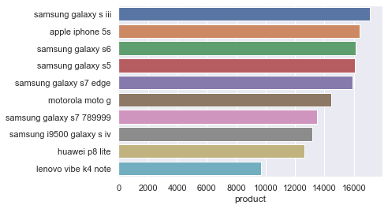

```python
product = df['product'].value_counts()[:10]
print('Distribution of number of ratings per item (Clipped at 10): \n',product)
sns.barplot(y=product.index,x=product)
plt.show()
```

```
Distribution of number of ratings per user(Clipped at 10):
 Amazon Customer    76978
NaN                63202
Cliente Amazon     19304
e-bit               8663
Client d'Amazon     7716
Amazon Kunde        4750
Anonymous           2750
einer Kundin        2610
einem Kunden        1898
unknown             1738
Name: author, dtype: int64
```

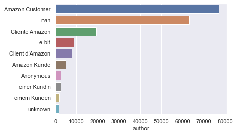

```python
users = df['author'].value_counts(dropna=False)[:10]
print('Distribution of number of ratings per user(Clipped at 10): \n',users)
users.index = users.index.map(str)
sns.barplot(y=users.index,x=users)
plt.show()
```

Following observations are made:

Most active user is 'Amazon customer'

'Anonymous' and 'unknown' users are those whose names are not known. Thus we can use this to impute blank values in 'author' column

Many names are similar but in different languages like 'Amazon customer' and 'Cliente Amazon'. Let's search for these first and cleanup the differences due to language

```python
unknowns = ['Anonymous','einer Kundin','einem Kunden', 'unknown','Anonymous ']
df['author'].replace(to_replace = unknowns,
                          value = 'Anonymous',
                          inplace=True)
```

```
Distribution of number of ratings per user(Clipped at 10):
 Amazon Customer    76978
NaN                63202
Cliente Amazon     19304
Anonymous          10457
e-bit               8663
Client d'Amazon     7716
Amazon Kunde        4750
Александр           1071
David               1016
Сергей               904
Name: author, dtype: int64
```

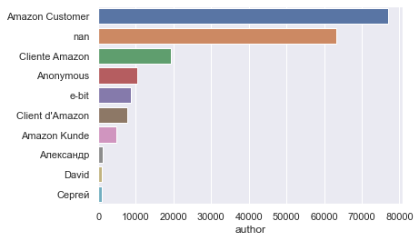

```python
users = df['author'].value_counts(dropna=False)[:10]
print('Distribution of number of ratings per user(Clipped at 10): \n',users)
users.index = users.index.map(str)
sns.barplot(y=users.index,x=users)
plt.show()
```

```python
df_new=df.copy()
```

### C. Round off scores to the nearest integers. [3 Marks]

```python
df_new['score'] = df_new['score'].round(0).astype('Int64')
print('Rounding-off: Unique values in the score after rounding-off: \n',list(df_new.score.unique()))
```

```
Rounding-off: Unique values in the score after rounding-off:
 [10, 6, 9, 4, 8, 2, 7, 5, <NA>, 3, 1, 0]
```

### D. Check for missing values. Impute the missing values, if any. [2 Marks]

```python
df_new.isnull().sum()
```

```
phone_url        0
date             0
lang             0
country          0
source           0
domain           0
score        63489
score_max    63489
extract      19361
author       63202
product          0
phone            0
dtype: int64
```

```python
df_new['score'] = df_new['score'].fillna(df_new['score'].median())
print('Imputation of score  with median')
df_new.isnull().sum()
```

```
Imputation of score  with median
```

```
phone_url        0
date             0
lang             0
country          0
source           0
domain           0
score            0
score_max    63489
extract      19361
author       63202
product          0
phone            0
dtype: int64
```

```python
df_new.dropna(inplace=True)
df_new = df_new[df_new["author"] != 'Anonymous']
print(f'df_new Shape(after removing missing values): Rows: {df_new.shape[0]} and Columns: {df_new.shape[1]}\n')
```

```
df_new Shape(after removing missing values): Rows: 1265609 and Columns: 12
```

```python
df_new.isnull().sum()
```

```
phone_url    0
date         0
lang         0
country      0
source       0
domain       0
score        0
score_max    0
extract      0
author       0
product      0
phone        0
dtype: int64
```

### E. Check for duplicate values and remove them, if any. [2 Marks]

```python
df_new = df_new.drop_duplicates()
print(f'df_new Shape(after removing duplicates): Rows: {df_new.shape[0]} and Columns: {df_new.shape[1]}\n')
```

```
ERROR! Session/line number was not unique in database. History logging moved to new session 171
df_new Shape(after removing duplicates): Rows: 1250545 and Columns: 12
```

### F. Keep only 1 Million data samples. Use random state=612. [2 Marks]

```python
df_1m = df_new.sample(n=1000000, random_state=612)
```

```python
df_1m.shape
```

```
(1000000, 12)
```

### G. Drop irrelevant features. Keep features like Author, Product, and Score. [2 Marks]

```python
relevant_features = ['author','product','score']
df1 = df_1m.loc[:,relevant_features]
print(f'data Shape after removing irrelevant features: Rows: {df1.shape[0]} and Columns: {df1.shape[1]}\n')
```

```
ERROR! Session/line number was not unique in database. History logging moved to new session 181
data Shape after removing irrelevant features: Rows: 1000000 and Columns: 3
```

## 2. Answer the following questions. [10 Marks]

```
            A. Identify the most rated features. [3 Marks]
            B. Identify the users with most number of reviews. [3 Marks]
            C. Select the data with products having more than 50 ratings and users who have given more than 50 ratings. Report the shape of the final dataset. [4 Marks]
```

### A. Identify the most rated features. [3 Marks]

```python
print('Most rated features/products: \n\n',df1['product'].value_counts().head())
```

```
Most rated features/products:

 samsung galaxy s6         12377
apple iphone 5s           11728
samsung galaxy s5         11602
motorola moto g           11514
samsung galaxy s7 edge    11225
Name: product, dtype: int64
```

**Most rated features are :**

> Samsung galaxy s6  
> Apple iphone 5s  
> Samsung galaxy s5  
> Motorola moto g  
> Samsung galaxy s7 edge

### B. Identify the users with most number of reviews. [3 Marks]

```python
print('Users with most number of reviews: \n\n',df1['author'].value_counts().head())
```

```
Users with most number of reviews:

 Amazon Customer    61417
Cliente Amazon     15424
e-bit               6728
Client d'Amazon     6156
Amazon Kunde        3780
Name: author, dtype: int64
```

**Users with most number of reviews are :**

> Amazon Customer Cliente Amazon  
> e-bit  
> Client d'Amazon  
> Amazon Kunde

### C. Select the data with products having more than 50 ratings and users who have given more than 50 ratings. Report the shape of the final dataset. [4 Marks]

```python
users_with_rating_more_than_50 = df1['author'].value_counts()[df1['author'].value_counts()>50].index.tolist()
print('Number of user who have given >50 rating: ', len(users_with_rating_more_than_50))

product_with_rating_more_than_50 = df1['product'].value_counts()[df1['product'].value_counts()>50].index.tolist()
print('Number of products with >50 rating: ', len(product_with_rating_more_than_50))

union_product_user_rating_more_than50 = df1[(df1['author'].isin(users_with_rating_more_than_50)) & (df1['product'].isin(product_with_rating_more_than_50))]
print(f'union_product_user_rating_more_than50: Rows: {union_product_user_rating_more_than50.shape[0]} and Columns: {union_product_user_rating_more_than50.shape[1]}\n')

union_product_user_rating_more_than50.head()
```

```
Number of user who have given >50 rating:  620
Number of products with >50 rating:  2206
union_product_user_rating_more_than50: Rows: 162473 and Columns: 3
```

|  | author | product | score |
| --- | --- | --- | --- |
| 359517 | Amazon Customer | motorola moto g4 | 6 |
| 227428 | Amazon Customer | htc one m9 | 2 |
| 317476 | Amazon-Kunde | cubot note s | 8 |
| 315569 | Amazon Customer | oppo f1s | 10 |
| 848015 | Christopher | apple iphone 5 | 2 |

**Data with products having more than 50 ratings and users who have given more than 50 ratings : Rows: 162473 and Columns: 3**

```python
union_product_user_rating_more_than50['author'].unique()[:100]
```

```
array(['Amazon Customer', 'Amazon-Kunde', 'Christopher', 'Lisa',
       'Cliente Amazon', 'Lorenzo', 'Jean', 'Nico', 'Ольга', 'Fabio',
       "Client d'Amazon", 'e-bit', 'Cristian', 'David', 'Michael', 'Mary',
       'claudio', 'Guido', 'Francesco', 'Fernando', 'Anônimo', 'Sara',
       'vincenzo', 'Diego', 'Brandon', 'Elena', 'Антон', 'bruno', 'Erkek',
       'Massimiliano', 'alex', 'Andrea', 'Kevin', 'daniel',
       'Amazon Kunde', 'Mike', 'Victor', 'Елена', 'Giovanni', 'Bert',
       'Jack', 'Paolo', 'Roy', 'Marco', 'Евгения', 'Alexander', 'Tim',
       'Naveen', 'Jan', 'Markus', 'Артём', 'monica', 'Giulio', 'Joseph',
       'Rose', 'Михаил', 'john', 'Rajesh', 'Fred', 'Anonyme', 'Jose',
       'marco', 'Jerry', 'Ricardo', 'Steven', '????????????', 'giuseppe',
       'stefano', 'Alberto', 'Bob', 'Pablo', 'Max', 'Davide', 'Andrew',
       'martin', 'Stefano', 'Nina', 'Tom', 'Dan', 'Juan', 'Robin',
       'Giuseppe', 'Kindle Customer', 'david', 'Rahul', 'Сергей',
       'Michelle', 'Mario', '???????�????', '???????????? ????????',
       'Julian', 'Client Amazon', 'Jen', 'Ashley', 'Marcus', 'Hans',
       'Deepak', 'Ed', 'Александр', 'Anónimo '], dtype=object)
```

```python
union_product_user_rating_more_than50['product'].unique()[:100]
```

```
array(['motorola moto g4', 'htc one m9', 'cubot note s', 'oppo f1s',
       'apple iphone 5', 'huawei honor 7', 'lenovo vibe k4 note',
       'xiaomi redmi note 2', 'blackberry q5', 'huawei ascend g750',
       'apple iphone se', 'nokia asha 302', 'oneplus 3t',
       'huawei honor 6x', 'xiaomi redmi note 3 pro',
       'samsung i8262 galaxy core duos', 'apple iphone 5s',
       'samsung galaxy ace s5830', 'microsoft lumia 550',
       'samsung gt e1200', 'vodafone smart ultra 6', 'doogee x5',
       'lenovo vibe k5', 'samsung i9500 galaxy s iv', 'blu vivo air',
       'samsung galaxy s7 789999', 'samsung brightside u380',
       'lenovo phab 2 plus', 'samsung galaxy s ii plus',
       'samsung galaxy s5', 'samsung galaxy s6', 'apple iphone 6s plus',
       'motorola moto g5', 'archos 50 diamond', 'samsung galaxy a3 2016',
       'lg optimus l5 ii dual e455 optimus duet', 'huawei honor 5x',
       'huawei honor 8', 'doogee valencia 2 y100 pro', 'yu yunique',
       'lg leon h324', 'motorola moto g 4 plus', 'nokia lumia 730',
       'samsung galaxy s4 mini gt i9190 gt i9192 dual sim',
       'samsung galaxy note iii', 'xiaomi mi 4i', 'blackberry priv',
       'apple iphone 5c', 'lg optimus l1 ii e420', 'samsung galaxy mini',
       'acer liquid z630', 'nokia e7', 'htc 10', 'nokia 808', 'oneplus 3',
       'lg g4', 'nokia asha 309', 'palm treo pro',
       'samsung galaxy s6 edge sm g925f', 'lg g2 594708',
       'motorola moto g3', 'micromax canvas unite 3 q372',
       'asus zenfone 2', 'apple iphone 6', 'motorola moto x',
       'blackberry torch 9800', 'lg volt ls740', 'lenovo moto g4 play',
       'oneplus x', 'samsung galaxy s iii', 'lg p970',
       'blu advance 4 0 l2', 'samsung galaxy s6 edgeplus',
       'samsung galaxy j5', 'samsung galaxy grand duos i9080 i9082',
       'samsung galaxy s5 mini', 'asus ze550kl', 'huawei p8 lite',
       'sony xperia m4', 'sony xperia z5',
       'samsung galaxy j5 4g lte 5 2 inches', 'apple iphone 4',
       'htc one m7', 'nokia 5320 xpressmusic', 'lenovo zuk z1',
       'oukitel k6000 pro', 'nokia n93', 'lg g3 d855 657484',
       'htc desire s', 'motorola razr v3', 'sony ericsson xperia x8',
       'asus zenfone selfie zd551kl', 'oneplus one 64gb',
       'asus zenfone 3 max', 'lg g3 stylus d690', 'htc inspire 4g',
       'huawei honor 6', 'lenovo a1000 dual sim 4 mobile phone',
       'samsung corbypro b5310', 'htc desire 620g'], dtype=object)
```

## 3. Build a popularity based model and recommend top 5 mobile phones. [5 Marks]

```python
def popularity_rec(data):
    ratings_mean_count = pd.DataFrame(data.groupby('product')['score'].mean())
    ratings_mean_count['rating_counts'] = data.groupby('product')['score'].count()
    ratings_mean_count = ratings_mean_count.sort_values(by=['score','rating_counts'], ascending=[False,False])
    print('Top 5 recommendations for the products are: \n')
    display(ratings_mean_count.head())
    return
```

[output not shown]

```python
# Using the data from the most popular phones amongst the most frequent users
popularity_rec(union_product_user_rating_more_than50)
```

```
Top 5 recommendations for the products are:
```

| product | score | rating_counts |
| --- | --- | --- |
| nokia 5250 | 10.0 | 8 |
| alcatel one touch idol x plus | 10.0 | 7 |
| samsung galaxy s relay 4g | 10.0 | 5 |
| acer liquid z5 duo | 10.0 | 4 |
| huawei ideos x5 | 10.0 | 4 |

> **Most popular phone (rated 10 by highest number of people) amongst the most frequent users:**
> > - Amongst top users: nokia 5250

```python
# if we consider the original data (excluding 'Anonymous' users)
popularity_rec(df1)
```

```
Top 5 recommendations for the products are:
```

| product | score | rating_counts |
| --- | --- | --- |
| xiaomi mi 5s | 10.0 | 8 |
| thl w7s | 10.0 | 6 |
| verykool t742 | 10.0 | 6 |
| blu studio c mini | 10.0 | 5 |
| lg p503 | 10.0 | 5 |

> **Most popular phone (rated 10 by highest number of people) original data (excluding 'Anonymous' users):**
> > - Overall: xiaomi mi 5s

```python
field_length = df1.author.astype(str).map(len)
print (df1.iloc[field_length.argmax(),0])
```

```
Darren Griffin The PocketPC Phone Edition market has been dominated for a long time by O2's XDA range which are available from many providers in various guises such as Orange's m1000 and m2000 as well as Qtek, MDA and many more and the recently released O
```

## 4. Build a collaborative filtering model using SVD. You can use SVD from surprise or build it from scratch(Note: Incase you’re building it from scratch you can limit your data points to 5000 samples if you face memory issues).

## Build a collaborative filtering model using kNNWithMeans from surprise. You can try both user-based and item-based model. [10 Marks]

### Collaborative filtering model using SVD

```python
# Rearrange columns for SVD and prepare train and testsets
df_50 = Dataset.load_from_df(union_product_user_rating_more_than50[['author','product','score']], Reader(rating_scale=(1, 10)))
trainset, testset = train_test_split(df_50, test_size=.25,random_state=612)

print('top 3 values from trainset: \n')
for key,value in {k: v for k, v in trainset.ur.items() if k <= 2}.items(): print(key,'-> ',value,'\n')
print('\ntop 3 values from testset: ', *testset[0:3], sep='\n\n')
```

```
top 3 values from trainset:

0 ->  [(0, 4.0), (1, 8.0), (2, 10.0), (4, 10.0), (8, 6.0), (14, 8.0), (15, 2.0), (18, 8.0), (19, 4.0), (20, 2.0), (22, 8.0), (23, 8.0), (30, 6.0), (20, 2.0), (34, 2.0), (23, 10.0), (4, 10.0), (37, 10.0), (43, 10.0), (20, 4.0), (47, 8.0), (48, 8.0), (49, 10.0), (50, 2.0), (20, 6.0), (20, 10.0), (53, …

1 ->  [(3, 6.0), (244, 10.0), (250, 2.0), (150, 10.0), (513, 10.0), (529, 2.0), (453, 10.0), (785, 10.0), (36, 6.0), (817, 2.0), (157, 8.0), (183, 10.0), (235, 6.0), (473, 2.0), (339, 6.0), (133, 6.0), (95, 2.0), (138, 10.0), (1145, 6.0), (1023, 2.0), (186, 10.0), (809, 2.0), (308, 10.0), (274, 10.0…

2 ->  [(5, 10.0), (7, 10.0), (9, 6.0), (10, 2.0), (12, 10.0), (13, 10.0), (21, 6.0), (29, 8.0), (38, 2.0), (55, 2.0), (57, 10.0), (62, 10.0), (76, 10.0), (32, 10.0), (15, 10.0), (114, 10.0), (118, 8.0), (137, 10.0), (6, 6.0), (163, 2.0), (174, 2.0), (188, 10.0), (16, 10.0), (97, 2.0), (6, 10.0), (18…


top 3 values from testset:

('Juan', 'wiko jerry', 8.0)

('Paolo', 'huawei ascend g7', 10.0)

('Amazon Customer', 'sony xperia z1', 10.0)
```

```python
def get_top_n(predictions, n=5):
    # First map the predictions to each user.
    top_n = defaultdict(list)
    for uid, iid, true_r, est, _ in predictions:
        top_n[uid].append((iid, est))

    # Then sort the predictions for each user and retrieve the n highest ones.
    for uid, user_ratings in top_n.items():
        user_ratings.sort(key=lambda x: x[1], reverse=True)
        top_n[uid] = user_ratings[:n]

    return top_n
```

```python
%%time
# fit and predict using svd
def svd_func(train, test):
    svd = SVD(random_state=612)
    svd.fit(train)
    svd_pred = svd.test(test)
    return svd_pred, svd

svd_pred, svd = svd_func(trainset,testset)
print('First few prediction values: \n',svd_pred[0:2])
print('\nRMSE value(test-set): ',round(accuracy.rmse(svd_pred),2),'\n')
svd_rmse = round(accuracy.rmse(svd_pred),2)
```

```
ERROR! Session/line number was not unique in database. History logging moved to new session 190
First few prediction values:
 [Prediction(uid='Juan', iid='wiko jerry', r_ui=8.0, est=7.035829050430087, details={'was_impossible': False}), Prediction(uid='Paolo', iid='huawei ascend g7', r_ui=10.0, est=7.418476450434635, details={'was_impossible': False})]
RMSE: 2.8369

RMSE value(test-set):  2.84

RMSE: 2.8369
CPU times: user 5.96 s, sys: 63.9 ms, total: 6.02 s
Wall time: 6.12 s
```

### Collaborative filtering model using kNNWithMeans_Item based

```python
%%time
# fit and predict using knn
def knn_item(train, test):
    knn_i = KNNWithMeans(k=50, sim_options={'name': 'pearson_baseline', 'user_based': False})
    knn_i.fit(train)
    knn_i_pred = knn_i.test(test)
    return knn_i_pred, knn_i

knn_i_pred, knn_i = knn_item(trainset, testset)
print('First few prediction values: \n',knn_i_pred[0:2])
print('\nRMSE value(Item-based Model, test-set): ',round(accuracy.rmse(knn_i_pred),2),'\n') # compute RMSE
knn_i_rmse = round(accuracy.rmse(knn_i_pred),2)
```

```
Estimating biases using als...
Computing the pearson_baseline similarity matrix...
Done computing similarity matrix.
First few prediction values:
 [Prediction(uid='Juan', iid='wiko jerry', r_ui=8.0, est=7.217335640496708, details={'actual_k': 50, 'was_impossible': False}), Prediction(uid='Paolo', iid='huawei ascend g7', r_ui=10.0, est=9.292202571250861, details={'actual_k': 50, 'was_impossible': False})]
RMSE: 2.8303

RMSE value(Item-based Model, test-set):  2.83

RMSE: 2.8303
CPU times: user 11min 30s, sys: 5.51 s, total: 11min 36s
Wall time: 11min 42s
```

### Collaborative filtering model using kNNWithMeans_User based

```python
%%time
# fit and predict using knn
def knn_user(train, test):
    knn_u = KNNWithMeans(k=50, sim_options={'name': 'pearson_baseline', 'user_based': True})
    knn_u.fit(train)
    knn_u_pred = knn_u.test(test)
    return knn_u_pred, knn_u

knn_u_pred, knn_u = knn_user(trainset, testset)
print('First few prediction values: \n',knn_u_pred[0:2])
print('\nRMSE value(User-based Model, test-set): ',round(accuracy.rmse(knn_u_pred),2),'\n') # compute RMSE
knn_u_rmse = round(accuracy.rmse(knn_u_pred),2)
```

```
Estimating biases using als...
Computing the pearson_baseline similarity matrix...
Done computing similarity matrix.
First few prediction values:
 [Prediction(uid='Juan', iid='wiko jerry', r_ui=8.0, est=8.586879122752961, details={'actual_k': 10, 'was_impossible': False}), Prediction(uid='Paolo', iid='huawei ascend g7', r_ui=10.0, est=8.687858992394085, details={'actual_k': 50, 'was_impossible': False})]
RMSE: 2.8320

RMSE value(User-based Model, test-set):  2.83

RMSE: 2.8320
CPU times: user 18.7 s, sys: 107 ms, total: 18.9 s
Wall time: 19 s
```

**RMSE**

> **SVD** : 2.84  
> **KNN mean with Item based** : 2.8303  
> **KNN mean with user based** : 2.8320

## 5. Evaluate the collaborative model. Print RMSE value. [2 Marks]

```
SVD : 2.84
KNN mean with Item based  : 2.83
KNN mean with user based: 2.83
```

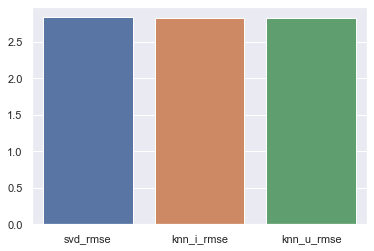

```python
print(f"SVD : {svd_rmse}")
print(f"KNN mean with Item based  : {knn_i_rmse}")
print(f"KNN mean with user based: {knn_u_rmse}")

sns.barplot(x=['svd_rmse','knn_i_rmse', 'knn_u_rmse'],y=[svd_rmse,knn_i_rmse, knn_u_rmse])
```

**Here we cans see that the best result is shown by kNNWithMeans_Item based**

## 6. Predict score (average rating) for test users. [2 Marks]

```python
svd_pred_df=pd.DataFrame(svd_pred, columns=['uid', 'iid', 'rui', 'est', 'details'])
print('average prediction for test users: ',svd_pred_df['est'].mean())
print('average rating  by test users: ',svd_pred_df['rui'].mean())
print('average prediction error for test users: ',(svd_pred_df['rui']-svd_pred_df['est']).abs().mean())
```

```
average prediction for test users:  7.8146457389609
average rating  by test users:  7.731849627021837
average prediction error for test users:  2.255450764021815
```

```python
knn_i_pred_df=pd.DataFrame(knn_i_pred, columns=['uid', 'iid', 'rui', 'est', 'details'])
print('average prediction for test users: ',knn_i_pred_df['est'].mean())
print('average rating  by test users: ',knn_i_pred_df['rui'].mean())
print('average prediction error for test users: ',(knn_i_pred_df['rui']-knn_i_pred_df['est']).abs().mean())
```

```
average prediction for test users:  7.669582700091388
average rating  by test users:  7.731849627021837
average prediction error for test users:  2.2771431534024447
```

```python
knn_u_pred_df=pd.DataFrame(knn_u_pred, columns=['uid', 'iid', 'rui', 'est', 'details'])
print('average prediction for test users: ',knn_u_pred_df['est'].mean())
print('average rating  by test users: ',knn_u_pred_df['rui'].mean())
print('average prediction error for test users: ',(knn_u_pred_df['rui']-knn_u_pred_df['est']).abs().mean())
```

```
average prediction for test users:  7.678933000851402
average rating  by test users:  7.731849627021837
average prediction error for test users:  2.270025676318249
```

## 7. Report your findings and inferences. [2 Marks]

> **Most popular phone (rated 10 by highest number of people):**
> > - Overall: xiaomi mi 5s
> > - Amongst top users: nokia 5250

> Data is seems to behighly skewed towards 'Amazon customers' from different countries. This is also expected due to popularity of Amazon. Though correct 'user' names from 'Amazon' should have used.

> Most of the authors have given the rating of '10' or '8'

> **RMSE Results**

> > **SVD** : 2.84  
> > **KNN mean with Item based** : 2.8303  
> > **KNN mean with user based** : 2.8320  
> > **Here we cans see that the best result is shown by kNNWithMeans_Item based**

> Both knn item-based and knn user-based have roughly similar RMSE

## 8. Try and recommend top 5 products for test users. [5 Marks]

```python
top_5 = get_top_n(knn_i_pred,5)
print('Top 5 recommendations for all test users are: \n')
for key,value in top_5.items(): print(key,'-> ',value,'\n')
```

```
Top 5 recommendations for all test users are:

Juan ->  [('sony xperia neo l', 10), ('samsung galaxy s7 789999', 9.54263358915438), ('samsung galaxy s7 789999', 9.54263358915438), ('xiaomi mi 3', 9.37227981912907), ('nokia lumia 520', 9.266955279916779)]

Paolo ->  [('huawei ascend mate 7', 9.76024955344742), ('huawei ascend mate 7', 9.76024955344742), ('huawei honor 6', 9.665385042316316), ('microsoft lumia 650', 9.665230946249446), ('google nexus 6p', 9.58068189461701)]

Amazon Customer ->  [('huawei ascend mate', 10), ('zte zmax 2', 10), ('oppo r7 plus', 10), ('nokia 7650', 10), ('asus zenfone 6', 10)]

Михаил ->  [('sony xperia z 504642', 9.81342954387981), ('samsung galaxy note 5 sm n920f', 9.784244788749755), ('htc desire z', 9.753698391946124), ('sony xperia z1', 9.724045458128874), ('apple iphone 5s', 9.629180291916676)]

Cliente Amazon ->  [('acer liquid e3 duo', 10), ('lenovo a806', 10), ('huawei nova plus', 10), ('nokia asha 503', 10), ('huawei nova plus', 10)]

Client d'Amazon ->  [('huawei honor 8', 9.48), ('huawei honor 8', 9.48), ('huawei honor 8', 9.48), ('huawei honor 8', 9.48), ('huawei honor 8', 9.48)]

max ->  [('lg optimus l5', 9.901471766649776), ('motorola va76r', 9.666929226253332), ('lg g2 594708', 9.62563175376971), ('asus zenfone 3', 9.321281321002585), ('nokia 5230', 9.056455784250309)]

Bezlikiy_Djo ->  [('nokia 5300 xpressmusic', 10), ('sony ericsson w610i', 10), ('nokia 5233', 9.34718961439054), ('nokia 6500 slide', 9.333796018550952), ('nokia n82', 8.302135419820324)]

Jeroen ->  [('samsung galaxy s7 edge', 9.975789164474628), ('htc one m9', 9.769431190381026), ('samsung galaxy s6', 9.295291068044357), ('sony xperia z5 premium', 9.173583783590866), ('htc 10', 8.979512059396006)]

oscar ->  [('htc 7 pro', 10), ('alcatel ot 355', 9.856258252147919), ('bq aquaris e5', 8.277087656577212), ('asus zenfone 3', 8.019229255232013), ('lg g2 594708', 7.994858835972222)]

Amazon Kunde ->  [('lg e440 optimus l4 ii', 10), ('htc 10', 9.898472506639084), ('htc 10', 9.898472506639084), ('nokia 9300', 9.764862171416848), ('apple iphone 6s plus', 9.694915646740053)]

Mario ->  [('nokia lumia 630', 9.515761207389954), ('nokia lumia 630', 9.515761207389954), ('motorola moto g', 9.418633016781135), ('motorola moto g', 9.418633016781135), ('apple iphone 5', 9.366651171857441)]

Paula ->  [('huawei p8 lite', 9.472453528582923), ('huawei p8 lite', 9.472453528582923), ('acer liquid z200', 8.671128476618483), ('elephone trunk', 8.657240814234562), ('leagoo lead 6', 7.983175682576027)]

sergio ->  [('asus ze550kl', 9.133114017646683), ('samsung galaxy grand neo gt i9060', 8.902070030632546), ('lg google nexus 5', 8.7177982743325), ('samsung galaxy note 2', 8.706164004772008), ('samsung galaxy k zoom', 8.682025730656976)]

e-bit ->  [('samsung galaxy a7 2017', 10), ('lg optimus g e977', 10), ('lg p725 optimus 3d max', 10), ('lg optimus g e977', 10), ('samsung galaxy a7 2017', 10)]

Nicolas ->  [('sony xperia z5', 9.421579883313292), ('motorola moto x play', 9.345529931097923), ('doro phone easy 615', 9.313170113859686), ('blackberry z30', 8.965681207949546), ('sony ericsson z610i', 8.903812287801536)]

Un anonyme ->  [('sony ericsson w810i', 9.413493069040468), ('sony ericsson k750i', 9.075897875240646), ('sony ericsson k750i', 9.075897875240646), ('sony ericsson k750i', 9.075897875240646), ('sony ericsson k750i', 9.075897875240646)]

David ->  [('htc aria', 10), ('htc 7 pro', 10), ('lg dare vx9700', 9.869286521927048), ('motorola moto x 1 moto x1 moto x 2nd gen', 9.790455153588473), ('nokia 6630', 9.784387419860263)]

Angela ->  [('apple iphone 6s', 9.748601957946976), ('huawei p8 lite', 9.645556373349596), ('samsung galaxy y s5360', 9.640894778741199), ('samsung galaxy s5', 9.618913785820295), ('huawei p9 lite', 9.584171475757094)]

```

[output cut: 1186 more lines]

```
K ->  [('samsung galaxy s7 edge', 9.604328730923696), ('xiaomi mi 3', 9.59578451908603), ('huawei p8 lite', 7.9286391467388), ('ttfone pluto', 7.8820633531825095), ('samsung i9500 galaxy s iv', 6.842410541349726)]

Pete ->  [('lg optimus net', 9.609438810551866), ('sony xperia e5', 9.580662586173453), ('htc hd2', 9.121305935468193), ('htc one m7', 9.054772939949325), ('samsung galaxy note 4', 8.865590376542038)]

Roy ->  [('huawei honor 6x', 9.419457840340014), ('sony xperia t', 9.086975988035489), ('oneplus 3', 9.078237760844969), ('lg gt400', 8.782103845285096), ('sony xperia z5 premium', 8.767392209825507)]

Brandon ->  [('zte axon 7', 9.613149167026057), ('samsung galaxy s5', 8.735830943363267), ('huawei honor 5x', 8.723529020013384), ('apple iphone 5', 8.631935212844276), ('samsung galaxy g130 young 2', 8.246979853661477)]

Santiago ->  [('xiaomi mi 3', 10), ('xiaomi mi 3', 10), ('samsung galaxy s6', 9.734381268088054), ('nokia lumia 830', 9.463727856131731), ('nokia lumia 1320', 9.305069244373046)]

???????????????? ?????????????? ->  [('samsung galaxy pocket neo', 9.79392772034326), ('apple iphone 4s', 9.584492935074536), ('huawei ascend w1', 9.268017389360336), ('htc desire c golf wildfire c', 7.743155024325546), ('samsung galaxy nexus', 7.418529576811665)]

diego ->  [('motorola moto x 2', 10), ('nokia lumia 930', 9.97207431185844), ('huawei p8 lite', 9.620583660267402), ('huawei p8 lite', 9.620583660267402), ('sony xperia z 504642', 9.499933976171212)]

eduardo ->  [('nokia 500', 9.665510643413787), ('lg e450 optimus l5 ii', 8.621520522089519), ('samsung galaxy s7 edge', 7.8865479296437), ('samsung galaxy ace style', 7.544085882044406), ('samsung galaxy a3 2016', 7.060755777209273)]
```

## 9. Try other techniques (Example: cross validation) to get better results. [3 Marks]

```python
%%time
svd_cv = cross_validate(svd,df_50, measures=['RMSE'], cv=5, verbose=False)
print('\n Mean svd cv score:', round(svd_cv['test_rmse'].mean(),2),'\n')
svd_cv
```

```
 Mean svd cv score: 2.85

CPU times: user 33.1 s, sys: 200 ms, total: 33.3 s
Wall time: 33.6 s
```

```
{'test_rmse': array([2.84759213, 2.8616112 , 2.86126677, 2.86322977, 2.83212135]),
 'fit_time': (6.015571117401123,
  6.237499237060547,
  6.30832314491272,
  6.333976984024048,
  6.1174280643463135),
 'test_time': (0.323760986328125,
  0.336122989654541,
  0.17910313606262207,
  0.15661096572875977,
  0.32122015953063965)}
```

```python
%%time
knn_i_cv = cross_validate(knn_i,df_50, measures=['RMSE'], cv=5, verbose=False)
print('\n Mean knn_i_cv score:', round(knn_i_cv['test_rmse'].mean(),2),'\n')
knn_i_cv
```

```
Estimating biases using als...
Computing the pearson_baseline similarity matrix...
Done computing similarity matrix.
Estimating biases using als...
Computing the pearson_baseline similarity matrix...
Done computing similarity matrix.
Estimating biases using als...
Computing the pearson_baseline similarity matrix...
Done computing similarity matrix.
Estimating biases using als...
Computing the pearson_baseline similarity matrix...
Done computing similarity matrix.
Estimating biases using als...
Computing the pearson_baseline similarity matrix...
Done computing similarity matrix.

 Mean knn_i_cv score: 2.82

CPU times: user 39min 2s, sys: 8.39 s, total: 39min 11s
Wall time: 39min 14s
```

```
{'test_rmse': array([2.8347155 , 2.81597813, 2.80285155, 2.81154755, 2.82199789]),
 'fit_time': (149.3462212085724,
  142.8288390636444,
  112.01689028739929,
  113.8098418712616,
  106.5606107711792),
 'test_time': (373.680056810379,
  356.29359912872314,
  334.04802894592285,
  322.570894241333,
  342.4067032337189)}
```

```python
%%time
knn_u_cv = cross_validate(knn_u,df_50, measures=['RMSE'], cv=5, verbose=False)
print('\n Mean knn_u_cv score:', round(knn_u_cv['test_rmse'].mean(),2),'\n')
knn_u_cv
```

```
Estimating biases using als...
Computing the pearson_baseline similarity matrix...
Done computing similarity matrix.
Estimating biases using als...
Computing the pearson_baseline similarity matrix...
Done computing similarity matrix.
Estimating biases using als...
Computing the pearson_baseline similarity matrix...
Done computing similarity matrix.
Estimating biases using als...
Computing the pearson_baseline similarity matrix...
Done computing similarity matrix.
Estimating biases using als...
Computing the pearson_baseline similarity matrix...
Done computing similarity matrix.

 Mean knn_u_cv score: 2.82

CPU times: user 1min 24s, sys: 374 ms, total: 1min 24s
Wall time: 1min 24s
```

```
{'test_rmse': array([2.82514592, 2.81188573, 2.81419618, 2.82640157, 2.8378938 ]),
 'fit_time': (3.5652270317077637,
  3.3941609859466553,
  3.191143751144409,
  3.3279640674591064,
  3.2745630741119385),
 'test_time': (14.217402696609497,
  13.073851823806763,
  13.059069156646729,
  12.76109004020691,
  13.87279200553894)}
```

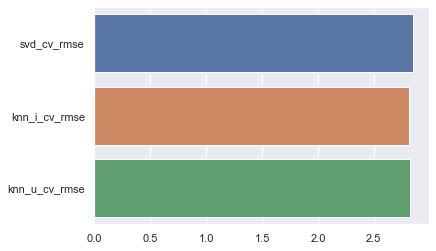

```python
# Comparison of RMSE scores(mean cv) from different collaorative algorithms
sns.barplot(y=['svd_cv_rmse','knn_i_cv_rmse', 'knn_u_cv_rmse'],
            x=[svd_cv['test_rmse'].mean(),knn_i_cv['test_rmse'].mean(), knn_u_cv['test_rmse'].mean()])
```

> **For cv scores too, knn mean with item based is giving a better performance as above. Though knn mean item based and user based has almost similar rmse**

## 10. In what business scenario you should use popularity based Recommendation Systems ? [2 Marks]

**Popularity basically uses the items which are in trend right now. Popularity based recommendation systems can be useful in multiple scenarios like:**

> When we have no data about the user and items.  
> When we need to show most popular items in different categories along with personalized results like:

> > Most popular trend in western wear or traditional wear  
> > Most popular punjabi songs or most popular english songs on a music website/app  
> > Most popular holiday packages for honeymoon trips, or bike trips or himalayan trips etc

## 11. In what business scenario you should use CF based Recommendation Systems ? [2 Marks]

**Collaborative filtering is useful in scenarios like:**

> Most websites like Amazon, YouTube, and Netflix use collaborative filtering as a part of their sophisticated recommendation systems. You can use this technique to build recommenders that give suggestions to a user on the basis of the likes and dislikes of similar users.

> Giving personalised recommendation to the user, when user history or item data is available. Examples:

> > Personalized movie recommendation of movie sites like Netflix, Amazon Prime and so on

## 12. What other possible methods can you think of which can further improve the recommendation for different users ? [2 Marks]

> **Apart from Popularity and Collaborative Filtering, hybrid recommendation methods like**

> > Content+Collaborative method ,  
> > Demographic,  
> > Utility based,  
> > Knowledge based recommendation system

====================================================================================================================

# END

====================================================================================================================